# Regression using K-Nearest Neighbour

Batch 47 - KNN INSOFE Lab Activity

28 October 2018

**NOTE** Before starting this activity please remember to clear your environment.

```r
  rm(list = ls(all=TRUE))
```

# Agenda

- Read the dataset
- Data pre-processing
- Explore the dataset
- Regression with K-Nearest Neigbour

# Problem Description

- In the following Supervised Learning activity, the Data file contains the Customer Data of a Game Store which makes revenue by selling Video Games. We need to predict the ‘TotalRevenueGenerated’

# Reading & Understanding the Data

- Make sure the dataset is located in your current working directory

```r
  # Load all packages
  library(class)   #knn
  library(caret)  #trainControl , train
```

- Setting the Working directory & reading the Data-File

```r
  # Use the setwd() function to get to the directory where the data is present

  setwd = getwd()

  data = read.csv("CustomerData.csv",header = TRUE,na.strings = c("#","NaN","@","NA"))

  str(data) #Checking the Data Types and their levels present in all the Featuresss
```

```
## 'data.frame':    3209 obs. of  14 variables:
##  $ CustomerID                  : int  1001 1002 1003 1004 1005 1006 1007 1008 1009 1010 ...
##  $ City                        : int  1 1 1 1 1 1 1 1 1 2 ...
##  $ NoOfChildren                : int  2 2 4 1 3 2 3 2 4 3 ...
##  $ MinAgeOfChild               : int  3 3 3 6 6 3 8 6 6 5 ...
##  $ MaxAgeOfChild               : int  8 6 5 6 9 4 12 8 9 6 ...
##  $ Tenure                      : int  210 442 424 261 422 378 369 404 420 333 ...
##  $ FrquncyOfPurchase           : int  11 20 18 11 44 16 25 13 20 15 ...
##  $ NoOfUnitsPurchased          : int  11 20 18 9 31 16 15 12 16 15 ...
##  $ FrequencyOFPlay             : int  2344 245 1059 365 1066 228 75 1488 2743 1967 ...
##  $ NoOfGamesPlayed             : int  108 22 130 34 102 12 2 118 163 56 ...
##  $ NoOfGamesBought             : int  10 7 18 11 44 16 25 13 16 15 ...
##  $ FavoriteChannelOfTransaction: Factor w/ 2 levels "Favorite","Uniform": 2 1 1 1 2 1 1 1 2 1 ...
##  $ FavoriteGame                : Factor w/ 2 levels "Favorite","Uniform": 2 2 2 2 2 1 1 2 2 2 ...
##  $ TotalRevenueGenerated       : num  108 382 135 125 335 ...
```

```r
  summary(data) #Obtaining the Summary Stats of the datasets
```

```
##    CustomerID        City        NoOfChildren    MinAgeOfChild
##  Min.   :1001   Min.   :1.000   Min.   : 1.000   Min.   :  0.000
##  1st Qu.:1803   1st Qu.:1.000   1st Qu.: 1.000   1st Qu.:  4.000
##  Median :2605   Median :1.000   Median : 2.000   Median :  5.000
##  Mean   :2605   Mean   :1.114   Mean   : 2.128   Mean   :  4.961
##  3rd Qu.:3407   3rd Qu.:1.000   3rd Qu.: 3.000   3rd Qu.:  6.000
##  Max.   :4209   Max.   :2.000   Max.   :11.000   Max.   :113.000
##  MaxAgeOfChild         Tenure      FrquncyOfPurchase NoOfUnitsPurchased
##  Min.   :  3.000   Min.   :100.0   Min.   :  1.00    Min.   :  1.00
##  1st Qu.:  6.000   1st Qu.:301.0   1st Qu.: 11.00    1st Qu.: 10.00
##  Median :  7.000   Median :368.0   Median : 14.00    Median : 13.00
##  Mean   :  7.991   Mean   :347.5   Mean   : 16.27    Mean   : 14.68
##  3rd Qu.:  8.000   3rd Qu.:417.0   3rd Qu.: 19.00    3rd Qu.: 17.00
##  Max.   :113.000   Max.   :472.0   Max.   :119.00    Max.   :112.00
##  FrequencyOFPlay NoOfGamesPlayed   NoOfGamesBought
##  Min.   :    0   Min.   :   0.00   Min.   :  0.00
##  1st Qu.:  446   1st Qu.:  37.00   1st Qu.: 10.00
##  Median : 1029   Median :  70.00   Median : 14.00
##  Mean   : 1568   Mean   :  93.63   Mean   : 14.76
##  3rd Qu.: 2029   3rd Qu.: 119.00   3rd Qu.: 19.00
##  Max.   :27829   Max.   :1166.00   Max.   :115.00
##  FavoriteChannelOfTransaction   FavoriteGame  TotalRevenueGenerated
##  Favorite:2637                Favorite: 126   Min.   :100.0
##  Uniform : 572                Uniform :3083   1st Qu.:116.6
##                                               Median :142.4
##                                               Mean   :168.5
##                                               3rd Qu.:191.2
##                                               Max.   :990.6
```

- Viewing the various features of the Data

```r
  dim(data) #See the No. row and columns
```

```
## [1] 3209   14
```

```r
  colnames(data) #Display the columns
```

```
##  [1] "CustomerID"                   "City"
##  [3] "NoOfChildren"                 "MinAgeOfChild"
##  [5] "MaxAgeOfChild"                "Tenure"
##  [7] "FrquncyOfPurchase"            "NoOfUnitsPurchased"
##  [9] "FrequencyOFPlay"              "NoOfGamesPlayed"
## [11] "NoOfGamesBought"              "FavoriteChannelOfTransaction"
## [13] "FavoriteGame"                 "TotalRevenueGenerated"
```

```r
  head(data) #See the top rows of the data
```

```
##   CustomerID City NoOfChildren MinAgeOfChild MaxAgeOfChild Tenure
## 1       1001    1            2             3             8    210
## 2       1002    1            2             3             6    442
## 3       1003    1            4             3             5    424
## 4       1004    1            1             6             6    261
## 5       1005    1            3             6             9    422
## 6       1006    1            2             3             4    378
##   FrquncyOfPurchase NoOfUnitsPurchased FrequencyOFPlay NoOfGamesPlayed
## 1                11                 11            2344             108
## 2                20                 20             245              22
## 3                18                 18            1059             130
## 4                11                  9             365              34
## 5                44                 31            1066             102
## 6                16                 16             228              12
##   NoOfGamesBought FavoriteChannelOfTransaction FavoriteGame
## 1              10                      Uniform      Uniform
## 2               7                     Favorite      Uniform
## 3              18                     Favorite      Uniform
## 4              11                     Favorite      Uniform
## 5              44                      Uniform      Uniform
## 6              16                     Favorite     Favorite
##   TotalRevenueGenerated
## 1                107.51
## 2                382.40
## 3                135.01
## 4                125.00
## 5                335.05
## 6                150.00
```

- Data Analysis

```r
  #Target Attribute Distribution
  attach(data)

  #FavoriteGame Coloumn Distribution
  table(data$FavoriteGame) #For Retreiving the count of the levels in the coloumn
```

```
##
## Favorite  Uniform
##      126     3083
```

```r
  prop.table(table(data$FavoriteGame)) #For Retreiving the percentage of the levels in the coloumn
```

```
##
##   Favorite    Uniform
## 0.03926457 0.96073543
```

```r
  #FavoriteChannelOfTransaction Coloumn Distribution
  table(data$FavoriteChannelOfTransaction)
```

```
##
## Favorite  Uniform
##     2637      572
```

```r
  prop.table(table(data$FavoriteChannelOfTransaction))
```

```
##
##  Favorite   Uniform
## 0.8217513 0.1782487
```

- Data Preparation

```r
  # Observations:
  #   1. City is interpreted as numeric (which is actually categorical) and FavouriteGame,
  #      FavouriteChannelOfTransaction are interpreted as objects.
  #   2. max age of children is 113 which must be a wrong entry
  #   3. Summary statistics for CustomerID is not meaningful
  #
  #   So we now change these appropriately i.e, convert city, favourite game and favourite channel to
  #   category, exclude customer id from the data for analysis and treat wrong entry records

  #Check and delete CustomerID attribute
  data$CustomerID = NULL
  # View(data)

  #Data Type conversion
  #Using 'as.factor' to convert City', 'FavoriteChannelOfTransaction', 'FavoriteGame' attributes to categorical attributes

  cat_cols = c("City", "FavoriteChannelOfTransaction", "FavoriteGame")
  data[cat_cols] = lapply(data[cat_cols], as.factor)
  str(data)
```

```
## 'data.frame':    3209 obs. of  13 variables:
##  $ City                        : Factor w/ 2 levels "1","2": 1 1 1 1 1 1 1 1 1 2 ...
##  $ NoOfChildren                : int  2 2 4 1 3 2 3 2 4 3 ...
##  $ MinAgeOfChild               : int  3 3 3 6 6 3 8 6 6 5 ...
##  $ MaxAgeOfChild               : int  8 6 5 6 9 4 12 8 9 6 ...
##  $ Tenure                      : int  210 442 424 261 422 378 369 404 420 333 ...
##  $ FrquncyOfPurchase           : int  11 20 18 11 44 16 25 13 20 15 ...
##  $ NoOfUnitsPurchased          : int  11 20 18 9 31 16 15 12 16 15 ...
##  $ FrequencyOFPlay             : int  2344 245 1059 365 1066 228 75 1488 2743 1967 ...
##  $ NoOfGamesPlayed             : int  108 22 130 34 102 12 2 118 163 56 ...
##  $ NoOfGamesBought             : int  10 7 18 11 44 16 25 13 16 15 ...
##  $ FavoriteChannelOfTransaction: Factor w/ 2 levels "Favorite","Uniform": 2 1 1 1 2 1 1 1 2 1 ...
##  $ FavoriteGame                : Factor w/ 2 levels "Favorite","Uniform": 2 2 2 2 2 1 1 2 2 2 ...
##  $ TotalRevenueGenerated       : num  108 382 135 125 335 ...
```

- Removing the Irrelevant Records

```r
  #Observe how many records have values 113 as age of the children

  temp_df = data[(data$MinAgeOfChild==113 | data$MaxAgeOfChild==113),]
  # View(temp_df)
  dim(temp_df)
```

```
## [1] 20 13
```

```r
  data = data[!(data$MinAgeOfChild==113 | data$MaxAgeOfChild==113),]
  # View(data)
  dim(data)
```

```
## [1] 3189   13
```

- Checking Missing Data

Missing Data ‘R’ primarily uses the value NA to represent missing data.

Check for missing value is.na() - output boolean i.e. if missing value then true else false. sum function counts ‘true’ thus gives total number of missing values

```r
  sum(is.na(data))
```

```
## [1] 0
```

```r
  str(data)
```

```
## 'data.frame':    3189 obs. of  13 variables:
##  $ City                        : Factor w/ 2 levels "1","2": 1 1 1 1 1 1 1 1 1 2 ...
##  $ NoOfChildren                : int  2 2 4 1 3 2 3 2 4 3 ...
##  $ MinAgeOfChild               : int  3 3 3 6 6 3 8 6 6 5 ...
##  $ MaxAgeOfChild               : int  8 6 5 6 9 4 12 8 9 6 ...
##  $ Tenure                      : int  210 442 424 261 422 378 369 404 420 333 ...
##  $ FrquncyOfPurchase           : int  11 20 18 11 44 16 25 13 20 15 ...
##  $ NoOfUnitsPurchased          : int  11 20 18 9 31 16 15 12 16 15 ...
##  $ FrequencyOFPlay             : int  2344 245 1059 365 1066 228 75 1488 2743 1967 ...
##  $ NoOfGamesPlayed             : int  108 22 130 34 102 12 2 118 163 56 ...
##  $ NoOfGamesBought             : int  10 7 18 11 44 16 25 13 16 15 ...
##  $ FavoriteChannelOfTransaction: Factor w/ 2 levels "Favorite","Uniform": 2 1 1 1 2 1 1 1 2 1 ...
##  $ FavoriteGame                : Factor w/ 2 levels "Favorite","Uniform": 2 2 2 2 2 1 1 2 2 2 ...
##  $ TotalRevenueGenerated       : num  108 382 135 125 335 ...
```

```r
  # In this case there are no missing values. However if we find any missing values in the data, as a rule of thumb
  #
  #   (A)If the particular row/column has more number of missing values then drop that particular rows/column
  #
  #     e.g. To drop any rows that have missing data use 'drop_na(dataframe)'
  #
  #   (B)Otherwise, impute/fill missing data based on domain knowledge or using imputation techniques
  #
  #     e.g. To fill missing values with mean use 'CentralImputation' or 'KNNImputation'
```

- Finding Correlation between Numerical Attributes

```r
  library(dplyr) #Loading 'dplyr' package for selecting numeric attributes
  num_attrbs = select_if(data, is.numeric)
  str(num_attrbs)
```

```
## 'data.frame':    3189 obs. of  10 variables:
##  $ NoOfChildren         : int  2 2 4 1 3 2 3 2 4 3 ...
##  $ MinAgeOfChild        : int  3 3 3 6 6 3 8 6 6 5 ...
##  $ MaxAgeOfChild        : int  8 6 5 6 9 4 12 8 9 6 ...
##  $ Tenure               : int  210 442 424 261 422 378 369 404 420 333 ...
##  $ FrquncyOfPurchase    : int  11 20 18 11 44 16 25 13 20 15 ...
##  $ NoOfUnitsPurchased   : int  11 20 18 9 31 16 15 12 16 15 ...
##  $ FrequencyOFPlay      : int  2344 245 1059 365 1066 228 75 1488 2743 1967 ...
##  $ NoOfGamesPlayed      : int  108 22 130 34 102 12 2 118 163 56 ...
##  $ NoOfGamesBought      : int  10 7 18 11 44 16 25 13 16 15 ...
##  $ TotalRevenueGenerated: num  108 382 135 125 335 ...
```

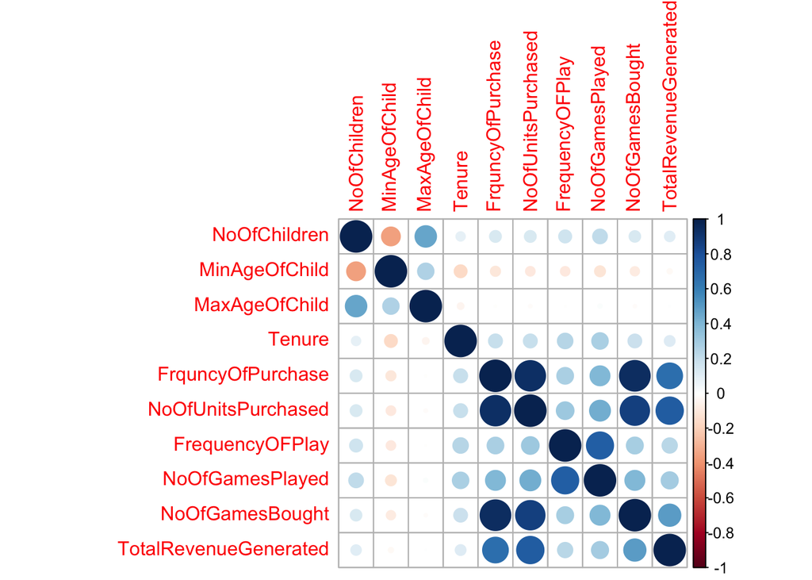

```r
  library(corrplot)
  #Approach-1:
    # cor_var = cor(num_attrbs)
    # op = corrplot(cor_var)

  #Approach-2:
  op = corrplot(cor(num_attrbs))
```

```r
  op
```

```
##                       NoOfChildren MinAgeOfChild MaxAgeOfChild      Tenure
## NoOfChildren            1.00000000   -0.35249942   0.461332151  0.08658319
## MinAgeOfChild          -0.35249942    1.00000000   0.267846448 -0.16315477
## MaxAgeOfChild           0.46133215    0.26784645   1.000000000 -0.04409811
## Tenure                  0.08658319   -0.16315477  -0.044098105  1.00000000
## FrquncyOfPurchase       0.13850722   -0.10104056  -0.004977328  0.19267247
## NoOfUnitsPurchased      0.13824432   -0.09163769  -0.012760656  0.19155512
## FrequencyOFPlay         0.16653570   -0.09015244  -0.002392557  0.24003489
## NoOfGamesPlayed         0.21422604   -0.11758011   0.017605750  0.27172387
## NoOfGamesBought         0.13184346   -0.08549426  -0.011047294  0.18771993
## TotalRevenueGenerated   0.10850914   -0.02753565   0.001928928  0.11524080
##                       FrquncyOfPurchase NoOfUnitsPurchased FrequencyOFPlay
## NoOfChildren                0.138507220         0.13824432     0.166535701
## MinAgeOfChild              -0.101040563        -0.09163769    -0.090152437
## MaxAgeOfChild              -0.004977328        -0.01276066    -0.002392557
## Tenure                      0.192672469         0.19155512     0.240034889
## FrquncyOfPurchase           1.000000000         0.93389444     0.278690286
## NoOfUnitsPurchased          0.933894436         1.00000000     0.310436445
## FrequencyOFPlay             0.278690286         0.31043645     1.000000000
## NoOfGamesPlayed             0.396332923         0.43456408     0.738154381
## NoOfGamesBought             0.947787521         0.86811298     0.285390183
## TotalRevenueGenerated       0.662371465         0.74967914     0.231888232
##                       NoOfGamesPlayed NoOfGamesBought
## NoOfChildren               0.21422604      0.13184346
## MinAgeOfChild             -0.11758011     -0.08549426
## MaxAgeOfChild              0.01760575     -0.01104729
## Tenure                     0.27172387      0.18771993
## FrquncyOfPurchase          0.39633292      0.94778752
## NoOfUnitsPurchased         0.43456408      0.86811298
## FrequencyOFPlay            0.73815438      0.28539018
## NoOfGamesPlayed            1.00000000      0.39794182
## NoOfGamesBought            0.39794182      1.00000000
## TotalRevenueGenerated      0.29139778      0.49444208
##                       TotalRevenueGenerated
## NoOfChildren                    0.108509136
## MinAgeOfChild                  -0.027535652
## MaxAgeOfChild                   0.001928928
## Tenure                          0.115240797
## FrquncyOfPurchase               0.662371465
## NoOfUnitsPurchased              0.749679143
## FrequencyOFPlay                 0.231888232
## NoOfGamesPlayed                 0.291397778
## NoOfGamesBought                 0.494442085
## TotalRevenueGenerated           1.000000000
```

- Converting Categorical to Numeric

```r
  #Removing Colloinear-Coloumns
  # As 'FrequencyofPurchase' and 'NoofunitsPurchased' have high collinearity with the Target Attribute, So we need to drop these features

  data$FrquncyOfPurchase <- NULL
  data$NoOfUnitsPurchased <- NULL



# Converting Categorical to Numeric
#   For some of the models all the independent attribute should be of type numeric and Linear Regression model is      one among them. Use library 'dummies' to convert convert categorical variable into dummy/indicator variables

  library(dummies)
  data=dummy.data.frame(data=data,names = c("City","FavoriteGame","FavoriteChannelOfTransaction"),sep = ".")
  str(data)
```

```
## 'data.frame':    3189 obs. of  14 variables:
##  $ City.1                               : int  1 1 1 1 1 1 1 1 1 0 ...
##  $ City.2                               : int  0 0 0 0 0 0 0 0 0 1 ...
##  $ NoOfChildren                         : int  2 2 4 1 3 2 3 2 4 3 ...
##  $ MinAgeOfChild                        : int  3 3 3 6 6 3 8 6 6 5 ...
##  $ MaxAgeOfChild                        : int  8 6 5 6 9 4 12 8 9 6 ...
##  $ Tenure                               : int  210 442 424 261 422 378 369 404 420 333 ...
##  $ FrequencyOFPlay                      : int  2344 245 1059 365 1066 228 75 1488 2743 1967 ...
##  $ NoOfGamesPlayed                      : int  108 22 130 34 102 12 2 118 163 56 ...
##  $ NoOfGamesBought                      : int  10 7 18 11 44 16 25 13 16 15 ...
##  $ FavoriteChannelOfTransaction.Favorite: int  0 1 1 1 0 1 1 1 0 1 ...
##  $ FavoriteChannelOfTransaction.Uniform : int  1 0 0 0 1 0 0 0 1 0 ...
##  $ FavoriteGame.Favorite                : int  0 0 0 0 0 1 1 0 0 0 ...
##  $ FavoriteGame.Uniform                 : int  1 1 1 1 1 0 0 1 1 1 ...
##  $ TotalRevenueGenerated                : num  108 382 135 125 335 ...
##  - attr(*, "dummies")=List of 3
##   ..$ City                        : int  1 2
##   ..$ FavoriteChannelOfTransaction: int  10 11
##   ..$ FavoriteGame                : int  12 13
```